# Gulf Fisheries Centre Age Estimation Structures collection - All taxa in one go

Daniel Ricard, Laurie Maynard and David Fishman

Last modified: May 28 2026

The [Age Estimation Structures collection held at the Gulf Fisheries Centre](https://dmapps/en/inventory/resources/98913402-688c-1615-9895-ec96b214be5a/) consists in *Teleost* saggital otoliths and *Chondrichthyan* vertebrae. For certain taxa, the physical specimens held in the collection are often accompanied with digital images. The individual details associated with each structure consists in capture date and location, length of individual and usually includes additional variables such as weight and maturity status.

The purpose of this notebook is to facilitate the generation and update of the FGP datasets associated with the Age Estimation Structures collection.

## Data dictionary

Generate the data dictionary.

## American Plaice

Otoliths from the September RV survey, from port sampling of commercial fisheries and from at-sea observers.

## Atlantic Cod

Otoliths from the September RV survey, from sentinel programs, from port sampling of commercial fisheries and from at-sea observers.

Unresolved issues: - observers data coming from read.card(sampling=“obs”) has erroneous dates for years 1994 to 2013 -> manually adding the year and setting month as “0” for now

## White Hake

Otoliths from the September RV survey, from port sampling of commercial fisheries and from at-sea observers.

## Winter Flounder

Otoliths from the September RV survey, from port sampling of commercial fisheries and from at-sea observers.

## Yellowtail Flounder

Otoliths from the September RV survey, and from port sampling of commercial fisheries and from at-sea observers.

Remaining issues: - are there really no commercial otoliths between 1982 and 2018?

## Witch Flounder

Otoliths from the September RV survey, from port sampling of commercial fisheries and from at-sea observers. Otoliths collected in the Quebec August survey in 4RS.

Unresolved issue: - 2025 commercial samples should’ve been received from Jerry Lavers but are not in our systems

## Atlantic Herring

Potential improvements: separate the source of the otoliths with a bit more nuance that “scientific surveys” and “other”

## Chondrichthyan vertebrae

Vertebrae from the September RV survey.

Outstanding issue: - there are no ages in the bio cards (ages were found on the science media drive under “Skate images”, still to be integrated into Oracle)

## Output

Finally, let’s write the full and partial data frames to CSV

```r
## replace month 0 with "unknown"
# idx <- which(payload$month_mois==13)
# payload[idx,"month_mois"] <- "unknown - inconnu"

out.fn <- "./output/NAFO-4T-age-estimation-structures-with-ages.csv"
write.csv(payload, file=out.fn, row.names = FALSE, fileEncoding = "UTF8")

# now without ages
out.fn <- "./output/NAFO-4T-age-estimation-structures.csv"
idx <- length(vars.bilingual)-1
new.cols <- vars.bilingual[0:idx]
write.csv(payload[new.cols], file=out.fn, row.names = FALSE, fileEncoding = "UTF8")
```

And for fun, make a few nice figures showing the number of otoliths over time and tabulate the number of otoliths in a summary table.

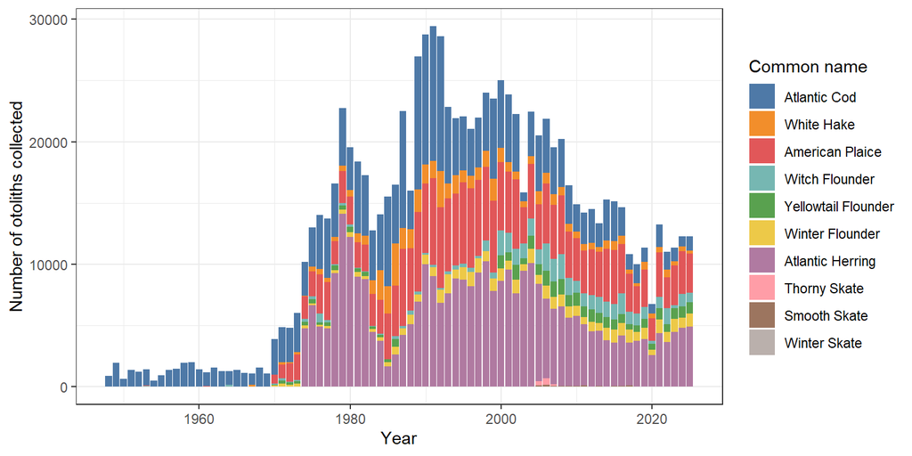

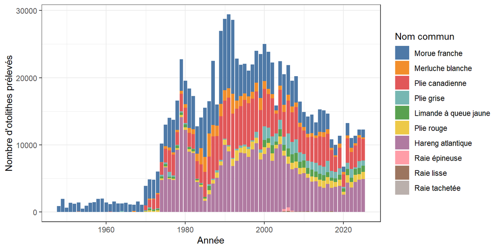

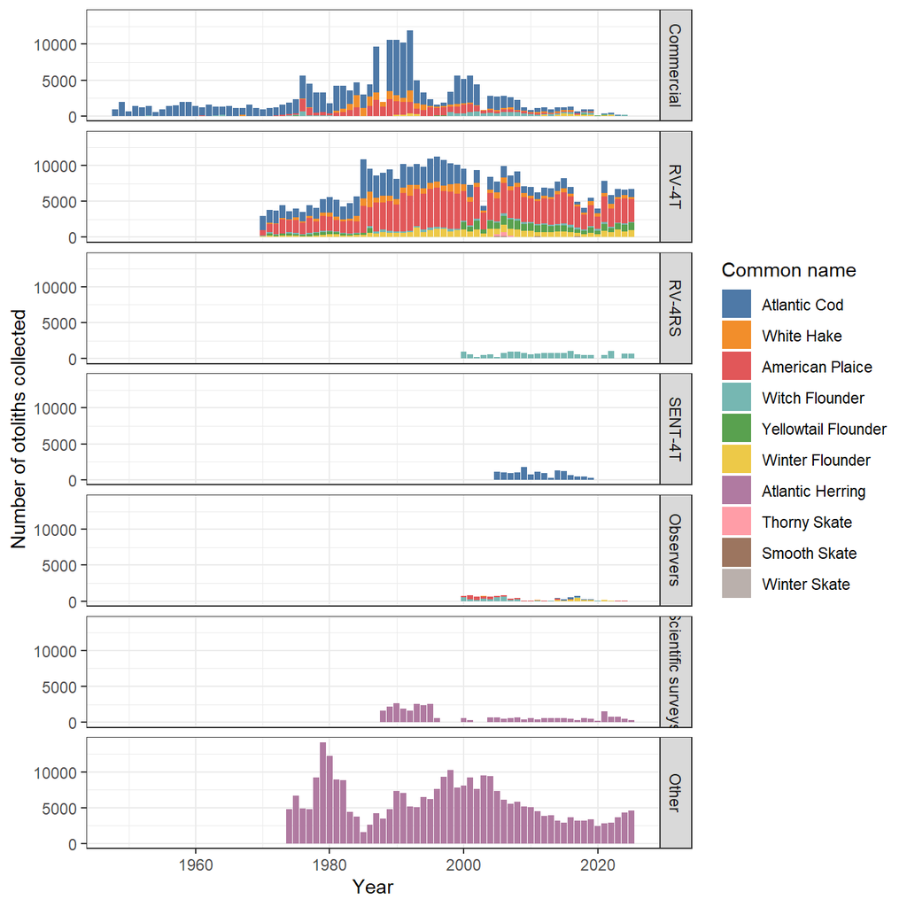

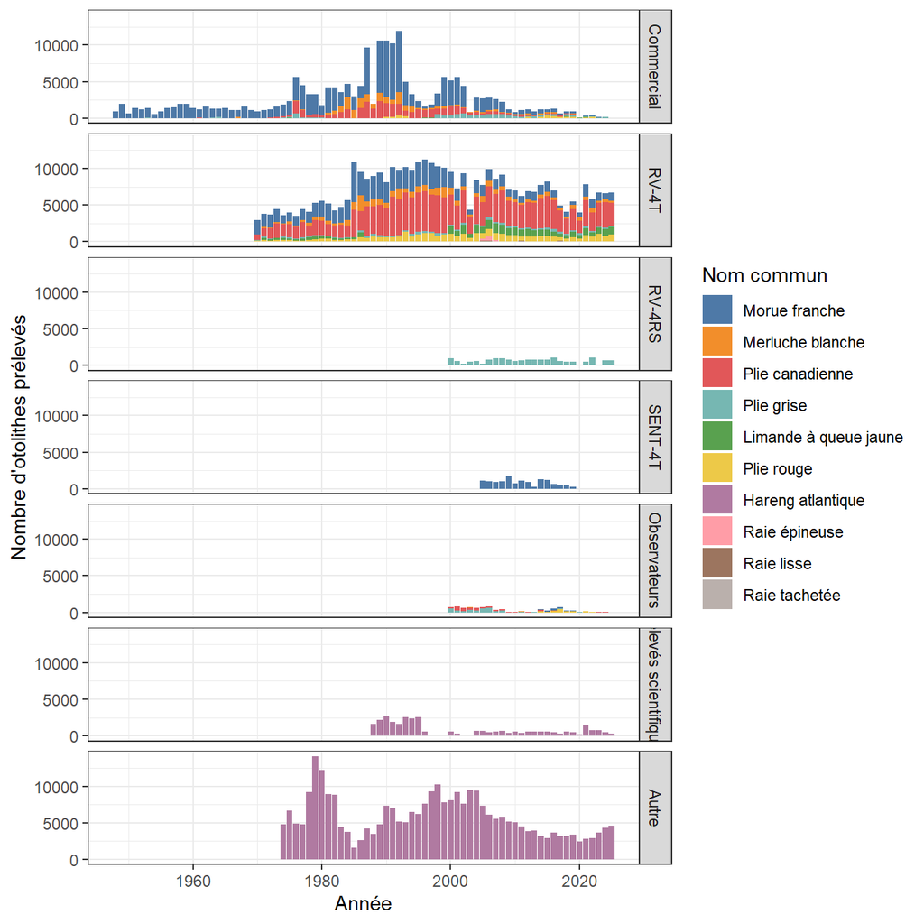

| english.name_nom.anglais | year_année | total.number_nombre.total | en.fac | ri |
| --- | --- | --- | --- | --- |
| Atlantic Cod | 1948 | 877 | 1 |  |
|  | 1949 | 1930 | 2 |  |
|  | 1950 | 629 | 3 |  |
|  | 1951 | 1357 | 4 |  |
|  | 1952 | 1200 | 5 |  |
|  | 1953 | 1304 | 6 |  |
|  | 1954 | 489 | 7 |  |
|  | 1955 | 912 | 8 |  |
|  | 1956 | 1352 | 9 |  |
|  | 1957 | 1480 | 10 |  |
|  | 1958 | 1950 | 11 |  |
|  | 1959 | 1991 | 12 |  |
|  | 1960 | 1394 | 13 |  |
|  | 1961 | 1138 | 14 |  |
|  | 1962 | 1553 | 15 |  |
|  | 1963 | 1221 | 16 |  |
|  | 1964 | 1078 | 17 |  |
|  | 1965 | 1360 | 18 |  |
|  | 1966 | 1123 | 19 |  |
|  | 1967 | 933 | 20 |  |
|  | 1968 | 1575 | 21 |  |
|  | 1969 | 1064 | 22 |  |
|  | 1970 | 2919 | 23 |  |
|  | 1971 | 2859 | 24 |  |
|  | 1972 | 2825 | 25 |  |
|  | 1973 | 3217 | 26 |  |
|  | 1974 | 2748 | 27 |  |
|  | 1975 | 3221 | 28 |  |
|  | 1976 | 4407 | 29 |  |
|  | 1977 | 4845 | 30 |  |

[output cut: 397 more lines]